# Predictive models

Based on the knowledge gained in the explanatory section, we wish to investigate the following questions:

- Can I predict if my flight will be cancelled?
- Can I predict if my flight will arrive late?

Both these questions can add value to both the customers, airlines and airports. Being able to predict cancelled flights will allow for better utilization of resources in an airport and allocation of planes. The customer will be able to stay home in case of a cancelled flight.

With respect to delays, we only focus on arrivals, mainly for the sake of brevity. However, it should be noted that attemps were made to predict departure delays, which showed results similar to arrival delays. This makes sense with respect to the correlation between them, as seen in the exploratory notebook.

The delays can add value in the same terms of optimization problems for airports and customers. Allocation of planes can be optimized and customer's arrival time to the airport.

We will apply three machine learning classifiers:

- Multi-layer Perceptrons
- Logistic Regression
- XGBoost

Developing and evaluating the models will make use of cross validation techniques, grid search, train test splits and downsampling to deal with the class imbalance problem.

## Installations and imports

The usual imports

```python
import pandas as pd
import numpy as np
import seaborn as sns
import matplotlib.pyplot as plt
import matplotlib as mpl
import sweetviz as sv
import plotly.graph_objects as go
import folium
import altair as alt
import warnings
warnings.filterwarnings('ignore')

%matplotlib inline

# Set figure size
mpl.rcParams['figure.figsize'] = [12, 8]

# Set colorblind theme for Francisco <3
sns.set_palette(sns.color_palette('colorblind'))
sns.set_theme()


# No limit on displaying columns of the dataframe
pd.set_option('display.max_columns', 500)
```

We import the cleaned data with no missing columns, except for the delays columns, which are NaN when the flight is cancelled

```python
df19 = pd.read_csv("Jan_2019_ontime_weather_imputed_clean.csv")
df20 = pd.read_csv("Jan_2020_ontime_weather_imputed_clean.csv")
```

In the dataset, there are way more non cancellations and delays than actual cancellations and delays. The cost of telling the client that they do not have to show up at the airport, because their flight is cancelled, but the flight is actually not cancelled (false positive) is high, due to them losing all the money they spent on the ticket. For false negatives, the cost is not as high, as the client will just find another plane with reimbursement.

Based on this, we choose the *f1 score* as a metric, which describes how well a model performs with respect to recall and precision. Rather than only how well it predicts the true cases which the accuracy measures. We could also choose the *roc area* as a metric, but f1 proved generally better results.

Even though cancellations would have a higher business impact, the prediction of delays are also of business interest, more specially for the airlines and their customer excelence, that's why we will also set as target the delays.

## Data processing

We will split the data into a training set to train the models on, a validation set to validate the hyperparameters and finally a test set to see the performance of the model on unseen data.

Since we have data for both 2019 and 2020, we will use the 2019 data for training and validation, and the 2020 data for testing. This way, we can show that the models are able to predict cancellations and delays in the future.

As some models are sensitive to the scale of continuous features, we will standardize the features as well.

We define a general function to make it easier to change properties of training data, such as features

```python
from sklearn.model_selection import train_test_split
from sklearn.preprocessing import OneHotEncoder, StandardScaler
```

```python
# Getting train test splits
def get_split(df, features, target, cat_cols=None, scale_cols=None, should_split=True):
    X = df[features]
    y = df[target]

    # One hot encode
    if cat_cols:
        cat_vars = df[cat_cols]

        enc = OneHotEncoder().fit(cat_vars)

        encoded_matrix = enc.transform(cat_vars)

        encoded_df = pd.DataFrame(encoded_matrix.toarray(), index=cat_vars.index, columns=enc.get_feature_names(cat_vars.columns.tolist()))

        X = pd.concat([X.drop(cat_cols, axis=1), encoded_df], axis=1)

    # Split
    # We stratify on our target (Cancellations) to get the same proportions of positive and negative cancellations
    X_train, X_val, y_train, y_val = train_test_split(X, y, stratify=y)

    # Scale
    if scale_cols:
        sc = StandardScaler().fit(X_train[scale_cols])
        X_train[scale_cols] = sc.transform(X_train[scale_cols])
        X_val[scale_cols] = sc.transform(X_val[scale_cols])

    if should_split:
        return X_train, X_val, y_train, y_val
    else:
        return X_train.append(X_val), y_train.append(y_val)
```

```python
def align_columns(X_test, X_train):
    missing_cols = set(X_train.columns).difference(set(X_test.columns))
    missing_cols2 = set(X_test.columns).difference(set(X_train.columns))

    if len(missing_cols) > 0:
        print('Columns missing from test set')
        print(missing_cols)
        X_test[list(missing_cols)] = 0

    if len(missing_cols2) > 0:
        print('Columns missing from train set')
        print(missing_cols2)
        X_test = X_test.drop(missing_cols2, axis=1)

    if len(missing_cols) + len(missing_cols2) == 0:
        print('Columns already match')

    return X_test
```

Train and test data separated into 2019 and 2020

```python
train_val_df = df19
test_df = df20
```

```python
train_val_df.CANCELLED.value_counts()
```

```
0    500665
1     14367
Name: CANCELLED, dtype: int64
```

For predicting delays, we will drop the missing values, as those are just the cancelled flights. (Cancellation leads to no delays)

```python
test_df_delay = df20.dropna()
```

### Cancellations

We chose the features based on weather, distance, time and carrier.

```python
org_weather = ['ORIGIN_tavg', 'ORIGIN_tmin', 'ORIGIN_tmax', 'ORIGIN_prcp', 'ORIGIN_snow', 'ORIGIN_wspd', 'ORIGIN_pres']
dest_weather = ['DEST_tavg', 'DEST_tmin', 'DEST_tmax', 'DEST_prcp', 'DEST_snow', 'DEST_wspd', 'DEST_pres']

location_col = ['DAY_OF_MONTH', 'DAY_OF_WEEK', 'OP_UNIQUE_CARRIER', 'DISTANCE']

features = org_weather + dest_weather + location_col
target = 'CANCELLED'
```

As we are dealing with a class imbalance problem, we downsample the non-cancellation, such that the distribution is close to 30%

```python
balanced_df = pd.concat([train_val_df.query('CANCELLED == 0').sample(30000, random_state=42),
                         train_val_df.query('CANCELLED == 1')])
balanced_df.CANCELLED.value_counts()
```

```
0    30000
1    14367
Name: CANCELLED, dtype: int64
```

For the sake of comparison, we also show how the models perform on the non balanced version.

The data is now split into a train and validation set with standardized numerical features and one-hot encoded categorical features.

```python
cat_cols = ['DAY_OF_MONTH', 'DAY_OF_WEEK', 'OP_UNIQUE_CARRIER']
scale_cols = ['DISTANCE']
```

```python
X_train, X_val, y_train, y_val = get_split(
    balanced_df, features, target,
    cat_cols=cat_cols,
    scale_cols=scale_cols
)

X_train_imb, X_val_imb, y_train_imb, y_val_imb = get_split(
    train_val_df, features, target,
    cat_cols=cat_cols,
    scale_cols=scale_cols
)
```

```python
X_test, y_test = get_split(
    test_df, features, target,
    cat_cols=cat_cols,
    scale_cols=scale_cols,
    should_split=False
)
```

Column mismatches, potentially through some airports existing in 2020 and not in 2019, and vice versa, will be detected and solved.

```python
X_test = align_columns(X_test, X_train)
```

```
Columns already match
```

```python
X_test.shape, X_train.shape
```

```
((533925, 70), (33275, 70))
```

The shapes match

### Delays

We will now prepare the data for delay targets.

To do so, we will apply the same techniques with respect to downsampling. Moreover, the target will only be ARR_DEL15, as we see that arrival delays are highly correlated with departure delays. This way, airports can also plan for delays of planes which have taken off, but not yet arrived at their destination.

```python
delay_features = ['DAY_OF_MONTH', 'DAY_OF_WEEK', 'OP_UNIQUE_CARRIER', 'DISTANCE', 'DEP_TIME']

features_arr = org_weather + dest_weather + delay_features

target_arr = 'ARR_DEL15'
```

```python
## Balanced data for arrival delays
#The sample size must be slightly bigger
arr_del_balanced_df = pd.concat([train_val_df.query('ARR_DEL15 == 0').sample(100000, random_state=42),
                         train_val_df.query('ARR_DEL15 == 1')])
arr_del_balanced_df.ARR_DEL15.value_counts()
```

```
0.0    100000
1.0     90761
Name: ARR_DEL15, dtype: int64
```

Drop rows where delay is missing (due to it being cancelled)

```python
arr_del_balanced_df = arr_del_balanced_df.dropna()
```

Splitting the data following same procedure as above.

```python
numerical_features_arr = ['DISTANCE', 'DEP_TIME']
cat_cols_arr = ['DAY_OF_MONTH', 'DAY_OF_WEEK', 'OP_UNIQUE_CARRIER']
```

```python
X_train_arr, X_val_arr, y_train_arr, y_val_arr = get_split(
    arr_del_balanced_df, features_arr, target_arr,
    cat_cols=cat_cols_arr,
    scale_cols=numerical_features_arr
)
```

```python
X_test_arr, y_test_arr = get_split(
    test_df_delay, features_arr, target_arr,
    cat_cols=cat_cols_arr,
    scale_cols=numerical_features_arr,
    should_split=False
)
```

```python
X_test_arr = align_columns(X_test_arr, X_train_arr)
```

```
Columns already match
```

```python
X_test_arr.shape, X_train_arr.shape
```

```
((526926, 71), (143070, 71))
```

## Utility functions

We define some functions to help evaluate the models more easily

```python
from sklearn.model_selection import cross_val_score
from sklearn.metrics import auc, accuracy_score, roc_curve, confusion_matrix
from sklearn.metrics import f1_score, recall_score, precision_score, roc_auc_score
```

```python
# Define evaluation
def evaluate_model(y_true, y_pred):
    print('F1 score', f1_score(y_true, y_pred))
    print('Recall', recall_score(y_true, y_pred))
    print('Precision', precision_score(y_true, y_pred))
    print('Accuracy', accuracy_score(y_true, y_pred))

def plot_roc(y_true, probs):
    """
    https://scikit-learn.org/stable/auto_examples/model_selection/plot_roc.html
    """
    fpr = dict()
    tpr = dict()
    roc_auc = dict()

    fpr, tpr, _ = roc_curve(y_true, probs)
    roc_auc = auc(fpr, tpr)

    plt.figure()
    lw = 2
    plt.plot(fpr, tpr, color='darkorange',
             lw=lw, label='ROC curve (area = %0.2f)' % roc_auc)
    plt.plot([0, 1], [0, 1], color='navy', lw=lw, linestyle='--')
    plt.xlim([0.0, 1.0])
    plt.ylim([0.0, 1.05])
    plt.xlabel('False Positive Rate')
    plt.ylabel('True Positive Rate')
    plt.title('ROC')
    plt.legend(loc="lower right")
    plt.show()

def plot_confusion(y_true, y_pred):
    cf_matrix = confusion_matrix(y_true, y_pred, normalize='all')
    plt.figure(figsize=(6, 5))

    cf = pd.DataFrame(cf_matrix)
    cf.index.name = 'Actual'
    cf.columns.name = 'Predicted'

    sns.heatmap(cf, annot=True, fmt='.2%')
    plt.show()
```

## Baseline

This model is based on flipping a coin. Hopefully, the real models will perform better than this

```python
from numpy.random import binomial
```

```python
y_pred = binomial(1, 0.5, len(y_train_imb))
```

```python
evaluate_model(y_train_imb, y_pred)
```

```
F1 score 0.05265922714753519
Recall 0.49772621809744777
Precision 0.027800240524176827
Accuracy 0.5004556351191123
```

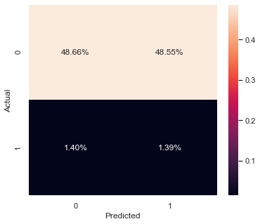

```python
plot_confusion(y_train_imb, y_pred)
```

The baseline predicts either 1 or 0, with a 50% chance. This adds up in terms of accuracy and confusion matrix. The confusion matrix is just the proportion of negative and positive predictions, as the model predicts 50% it will be evenly distributed across columns.

## MLP Classifier

We implement the MLP classifier

```python
from sklearn.neural_network import MLPClassifier
```

### Imbalanced vs Balanced Data

The nature of our data is clearly imbalanced, to see the impact of that we performed a prelimary analysis on whether which kind of data our models could predict better. The parameters for this prelimary analysis were chosen through trial and error and intuition. However, we will perform hyperparameter tuning to find the optimal set.

First we will start looking at the performance of the model with imbalanced data

```python
input_dim = X_train_imb.shape[1]

params = {
    'hidden_layer_sizes': (int(input_dim / 2), int(input_dim / 4), int(input_dim / 8)),
    'activation': 'relu',
    'solver': 'adam',
    'max_iter': 1000,
    'alpha': 0.00010
}
```

```python
mlp_imb = MLPClassifier(**params)
```

```python
%%time
scores = cross_val_score(mlp_imb, X_train_imb, y=y_train_imb, cv=5, scoring='f1', n_jobs=8, verbose=2)
scores
```

```
[Parallel(n_jobs=8)]: Using backend LokyBackend with 8 concurrent workers.
[Parallel(n_jobs=8)]: Done   2 out of   5 | elapsed:  4.7min remaining:  7.0min
[Parallel(n_jobs=8)]: Done   5 out of   5 | elapsed:  5.9min remaining:    0.0s
[Parallel(n_jobs=8)]: Done   5 out of   5 | elapsed:  5.9min finished
```

```
Wall time: 5min 54s
```

```
array([0.375     , 0.41044547, 0.41887724, 0.3720148 , 0.39447005])
```

Looking at the performance of the cross validation, it does seem to show some sign of overfitting. An generally the score is low.

```python
mlp_imb.fit(X_train_imb, y_train_imb)
```

```
MLPClassifier(hidden_layer_sizes=(35, 17, 8), max_iter=1000)
```

```python
y_pred = mlp_imb.predict(X_val_imb)
```

```python
evaluate_model(y_val_imb, y_pred)
```

```
F1 score 0.4441350504698921
Recall 0.35523385300668153
Precision 0.5923862581244197
Accuracy 0.9751937743674179
```

The accuracy is amazing, but looking at the other, more important metrics, such as F1 score. We see that the model does not perform too well. The recall is worse than the baseline.

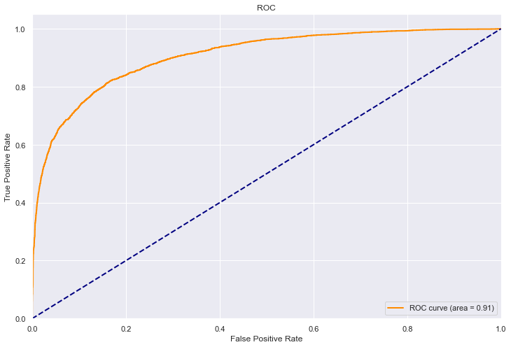

```python
plot_roc(y_val, mlp_imb.predict_log_proba(X_val)[:,1])
```

The ROC curve here is misleading, as it does indeed show a nice curve, closer to the top left and an area of 0.91.

However...

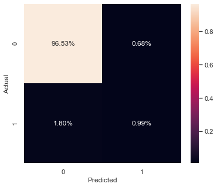

```python
plot_confusion(y_val_imb, y_pred)
```

The confusion matrix shows us that we have almost twice as many false negatives (no cancellation, while it actually will cancel)

We will now show the performance of the model with engineered data, i.e. data has been downsampled.

```python
params = {
    'hidden_layer_sizes': (int(input_dim / 2), int(input_dim / 4), int(input_dim / 8)),
    'activation': 'relu',
    'solver': 'adam',
    'max_iter': 1000,
    'alpha': 0.00010
}
```

```python
mlp = MLPClassifier(**params)
```

```python
%%time
scores = cross_val_score(mlp, X_train, y=y_train, cv=5, scoring='f1', n_jobs=8, verbose=2)
scores
```

```
[Parallel(n_jobs=8)]: Using backend LokyBackend with 8 concurrent workers.
[Parallel(n_jobs=8)]: Done   2 out of   5 | elapsed:    6.2s remaining:    9.4s
[Parallel(n_jobs=8)]: Done   5 out of   5 | elapsed:   12.7s remaining:    0.0s
[Parallel(n_jobs=8)]: Done   5 out of   5 | elapsed:   12.7s finished
```

```
Wall time: 13 s
```

```
array([0.73816761, 0.66856654, 0.73146961, 0.69426049, 0.71683272])
```

The model has little deviance in the cross validation performance, which shows little to no signs of overfitting. However, we'd like to improve the performance.

```python
mlp.fit(X_train, y_train)
```

```
MLPClassifier(hidden_layer_sizes=(35, 17, 8), max_iter=1000)
```

```python
y_pred = mlp.predict(X_val)
```

```python
evaluate_model(y_val, y_pred)
```

```
F1 score 0.5775829203202439
Recall 0.4217706013363029
Precision 0.9159613059250302
Accuracy 0.8002163721601154
```

The accuracy is not as great, but the f1 score is much better than previously, showing that the model is better at predicting cases of cancellations.

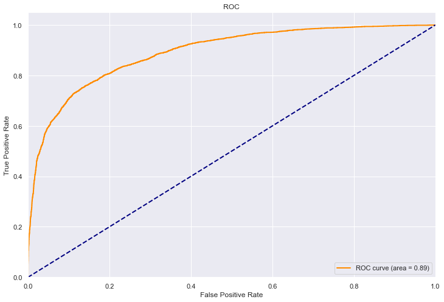

```python
plot_roc(y_val, mlp.predict_log_proba(X_val)[:,1])
```

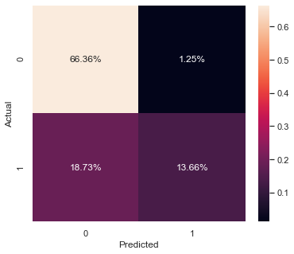

```python
plot_confusion(y_val, y_pred)
```

We also see that the model predicts more true positives, yet still has some inaccuracies of false positives and false negatives

As expected, the model with downsampled data performs significatly better, even though has some innaccuracies of false positives and false negatives, we can also see that the model predicts more true positive, which is afterall what we are looking for. That's why from now on we will downsampling our data, so we can overcome the classic imbalanced data problem.

### Cancellations

We will start with a model which will aim to predict the cancellations, as it is the target condition of most business relevance.

**Hyperparameter Tuning**

We will now use hyperparameter tuning on the network to find the best possible configuration for our model.

```python
from sklearn.model_selection import GridSearchCV
```

The set of parameters are chosen based on prior knowledge gained through development of this notebook. These values should cover some of the best cases we have seen thus far.

```python
input_dim = X_train.shape[1]

params1_can = {
    'hidden_layer_sizes': [(int(input_dim / 3), int(input_dim / 6), int(input_dim / 9))],
    'activation': ['relu'],
    'solver': ['adam'],
    'max_iter': [1000],
    'alpha': [1e-2, 5e-2, 1e-1],
    'early_stopping': [True],
    'epsilon': [1e-7, 1e-6, 1e-5, 1e-4]
}

params2_can = {
    'hidden_layer_sizes': [(int(input_dim / 2), int(input_dim / 4))],
    'activation': ['relu'],
    'solver': ['adam'],
    'max_iter': [1000],
    'alpha': [1e-2, 5e-2, 1e-1],
    'early_stopping': [True],
    'epsilon': [1e-7, 1e-6, 1e-5, 1e-4]
}

params3_can = {
    'hidden_layer_sizes': [(int(input_dim / 2), int(input_dim / 4), int(input_dim / 8), 5)],
    'activation': ['relu'],
    'solver': ['adam'],
    'max_iter': [1000],
    'alpha': [1e-2, 5e-2, 1e-1],
    'early_stopping': [True],
    'epsilon': [1e-6, 1e-5, 1e-4]
}
```

```python
param_grid_can = [
    params1_can,
    params2_can,
    params3_can
]

cv = StratifiedKFold(n_splits=5, random_state=42)
```

```python
clf_can = GridSearchCV(MLPClassifier(), param_grid_can, cv=cv, scoring='f1', n_jobs=8, verbose=2)
```

```python
%%time
clf_can.fit(X_train, y_train)
```

```
Fitting 5 folds for each of 33 candidates, totalling 165 fits
```

```
[Parallel(n_jobs=8)]: Using backend LokyBackend with 8 concurrent workers.
[Parallel(n_jobs=8)]: Done  25 tasks      | elapsed:   16.7s
[Parallel(n_jobs=8)]: Done 146 tasks      | elapsed:  1.3min
[Parallel(n_jobs=8)]: Done 165 out of 165 | elapsed:  1.5min finished
```

```
Wall time: 1min 35s
```

[output not shown]

```python
clf_can.cv_results_['mean_test_score']
```

```
array([0.71750238, 0.71898729, 0.70741284, 0.57651509, 0.70846408,
       0.56670405, 0.56301084, 0.70447237, 0.56799212, 0.70273628,
       0.69673659, 0.56828524, 0.71816162, 0.71950123, 0.71897505,
       0.71186375, 0.72294119, 0.71387643, 0.71394935, 0.70907797,
       0.71017999, 0.70095886, 0.71934901, 0.71483882, 0.71630786,
       0.42522798, 0.71115676, 0.70593324, 0.31267476, 0.70773579,
       0.56209574, 0.69196485, 0.41921024])
```

The model shows some strong signs of overfitting across the different folds

```python
clf_can.best_params_
```

```
{'activation': 'relu',
 'alpha': 0.05,
 'early_stopping': True,
 'epsilon': 1e-07,
 'hidden_layer_sizes': (35, 17),
 'max_iter': 1000,
 'solver': 'adam'}
```

The best neural net has 2 hidden layers with 35 and 17 nodes respectively

```python
y_pred = clf_can.predict(X_val)
```

```python
evaluate_model(y_val, y_pred)
```

```
F1 score 0.7161076995748701
Recall 0.6330734966592427
Precision 0.8242116708952519
Accuracy 0.8374504147133068
```

This model performs reasonably well on the validation set, achieving respectable values for all metrics.

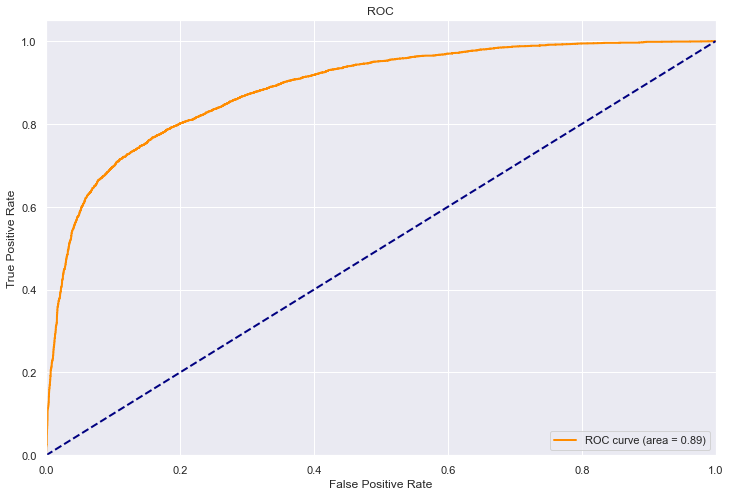

```python
plot_roc(y_val, clf_can.predict_log_proba(X_val)[:,1])
```

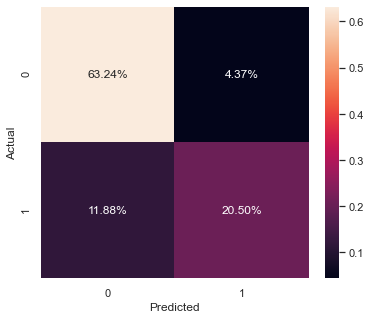

```python
plot_confusion(y_val, y_pred)
```

We also see that the model predicts more true positives, yet still has some inaccuracies of false positives and false negatives. However, not as much as with the imbalanced dataset.

Moreover, after performing grid search to find the optimal parameters, the general performance improved a lot compared to the untuned parameters shown in 'balanced data'

**Final evaluation on test data**

We will now evaluate the predictions on the test data

```python
y_pred = clf_can.predict(X_test)
```

```python
evaluate_model(y_test, y_pred)
```

```
F1 score 0.019246357533307005
Recall 0.07678275290215589
Precision 0.011002067343107668
Accuracy 0.911622418879056
```

We see a MASSIVE drop in performance, essentially the model is useless on the test data. We will discuss this further in the conclusion

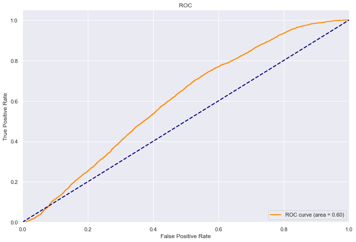

```python
plot_roc(y_test, clf_can.predict_log_proba(X_test)[:,1])
```

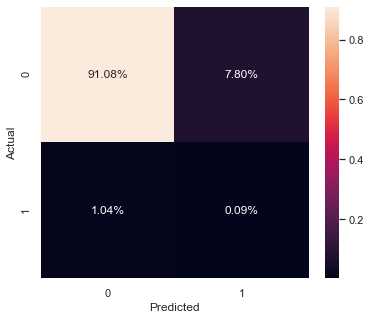

```python
plot_confusion(y_test, y_pred)
```

It seems that the model is overfitting on the train set and has no predictive capabilities on the test set. It tends to predict cancellations when there in fact are non (False positives)

### Arrival delay

Lastly, we will create a model which aims to predict arrival delays, even though the business relevance of predicting arrival delays is lesser than predicting cancellations, it is still of relevance as it can improve significantly the costumer experience.

**Hyperparameter Tuning**

As we did with the cancellations model, we will now use hyperparameter tuning on the network to find the best possible configuration

```python
from sklearn.model_selection import GridSearchCV
```

The set of parameters are chosen based on prior knowledge gained through development of this notebook. These values should cover some of the best cases we have seen thus far.

```python
input_dim = X_train_arr.shape[1]

params1_arr = {
    'hidden_layer_sizes': [(int(input_dim / 3), int(input_dim / 6), int(input_dim / 9))],
    'activation': ['relu'],
    'solver': ['adam'],
    'max_iter': [1000],
    'alpha': [1e-2, 5e-2, 1e-1],
    'early_stopping': [True],
    'epsilon': [1e-7, 1e-6, 1e-5, 1e-4]
}

params2_arr = {
    'hidden_layer_sizes': [(int(input_dim / 2), int(input_dim / 4))],
    'activation': ['relu'],
    'solver': ['adam'],
    'max_iter': [1000],
    'alpha': [1e-2, 5e-2, 1e-1],
    'early_stopping': [True],
    'epsilon': [1e-7, 1e-6, 1e-5, 1e-4]
}

params3_arr = {
    'hidden_layer_sizes': [(int(input_dim / 2), int(input_dim / 4), int(input_dim / 8), 5)],
    'activation': ['relu'],
    'solver': ['adam'],
    'max_iter': [1000],
    'alpha': [1e-2, 5e-2, 1e-1],
    'early_stopping': [True],
    'epsilon': [1e-6, 1e-5, 1e-4]
}
```

```python
param_grid_arr = [
    params1_arr,
    params2_arr,
    params3_arr
]

cv = StratifiedKFold(n_splits=5, random_state=42)
```

```python
clf_arr = GridSearchCV(MLPClassifier(), param_grid_arr, cv=cv, scoring='f1', n_jobs=8, verbose=2)
```

```python
%%time
clf_arr.fit(X_train_arr, y_train_arr)
```

```
Fitting 5 folds for each of 33 candidates, totalling 165 fits
```

```
[Parallel(n_jobs=8)]: Using backend LokyBackend with 8 concurrent workers.
[Parallel(n_jobs=8)]: Done  25 tasks      | elapsed:   56.2s
[Parallel(n_jobs=8)]: Done 146 tasks      | elapsed:  4.4min
[Parallel(n_jobs=8)]: Done 165 out of 165 | elapsed:  5.5min finished
```

```
Wall time: 5min 53s
```

[output not shown]

```python
clf_arr.cv_results_['mean_test_score']
```

```
array([0.60643151, 0.60660298, 0.38149485, 0.58727204, 0.61308389,
       0.60584257, 0.48212294, 0.59937073, 0.59000932, 0.61029496,
       0.48817549, 0.59727889, 0.61073838, 0.58423003, 0.61367406,
       0.61331918, 0.6099198 , 0.61632384, 0.61193996, 0.59973499,
       0.61339044, 0.60959987, 0.60942267, 0.59345049, 0.49722492,
       0.35660481, 0.59399335, 0.47648054, 0.62147572, 0.49873036,
       0.49184262, 0.40021546, 0.61248209])
```

The mean score is not particularly high and the deviations in scores show signs of overfitting

```python
clf_arr.best_params_
```

```
{'activation': 'relu',
 'alpha': 0.05,
 'early_stopping': True,
 'epsilon': 1e-05,
 'hidden_layer_sizes': (35, 17, 8, 5),
 'max_iter': 1000,
 'solver': 'adam'}
```

The best parameters for modelling delays shows that the neural network has 4 hidden layers of size (35, 17, 8, 5)

```python
y_pred_arr = clf_arr.predict(X_val_arr)
```

```python
evaluate_model(y_val_arr, y_pred_arr)
```

```
F1 score 0.5663230926651526
Recall 0.5000220351681284
Precision 0.6528944642651628
Accuracy 0.6356335576943238
```

This model is only slightly better than the baseline with respect to the accuracy but has a much better F1 score.

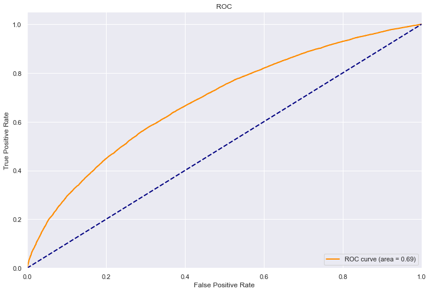

```python
plot_roc(y_val_arr, clf_arr.predict_log_proba(X_val_arr)[:,1])
```

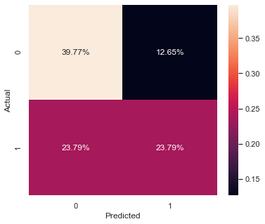

```python
plot_confusion(y_val_arr, y_pred_arr)
```

Both the ROC Curve and the confusion matrix indicates that the model is poor at predicting arrival delays, as it predicts approximately as many false negatives as true positives

**Final evaluation on test data**

We will now evaluate the predictions on the test data

```python
y_pred = clf_arr.predict(X_test_arr)
```

```python
evaluate_model(y_test_arr, y_pred)
```

```
F1 score 0.23629589766941256
Recall 0.40129072170746455
Precision 0.16744794569572946
Accuracy 0.6498787305997427
```

The model has clearly dropped in performance but not anywhere near the drop we saw under cancellations

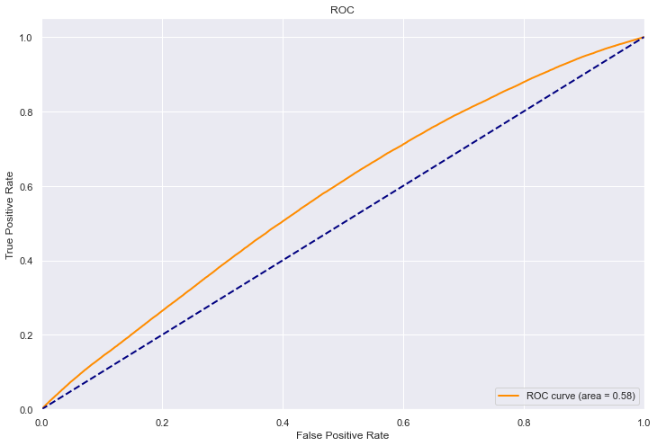

```python
plot_roc(y_test_arr, clf_arr.predict_log_proba(X_test_arr)[:,1])
```

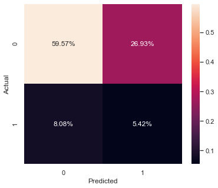

```python
plot_confusion(y_test_arr, y_pred)
```

Instead of predicting a lot of false negatives, it now predicts a lot of false positives, which we also see on the precision metric. The model is not very useful for predicting delays

## Logistic Regression

Next we will model the cancellations and delays with a logistic regression model

```python
from sklearn.linear_model import LogisticRegression
from sklearn.model_selection import StratifiedKFold, GridSearchCV
```

### Cancellations

Again the parameters were chosen based on prior knowledge. Moreover, we use an elasticnet penalty which is a combination of L1 and L2 regularization.

```python
param_grid_lr = [
    {
        'penalty': ['elasticnet'],
        'solver': ['saga'],
        'n_jobs': [8],
        'l1_ratio': np.linspace(0.001, 0.299, 5),
        'max_iter': [1000]
    }
]
```

Using stratified Kfold allows us to maintain the same proportions of positives and negatives between the folds.

```python
cv = StratifiedKFold(n_splits=5, random_state=42)
```

```python
lr_canc = GridSearchCV(LogisticRegression(), param_grid_lr, cv=cv, scoring='f1', n_jobs=8, verbose=2)
```

```python
%%time
lr_canc.fit(X_train, y_train)
```

```
Fitting 5 folds for each of 5 candidates, totalling 25 fits
```

```
[Parallel(n_jobs=8)]: Using backend LokyBackend with 8 concurrent workers.
[Parallel(n_jobs=8)]: Done  23 out of  25 | elapsed:   10.2s remaining:    0.8s
[Parallel(n_jobs=8)]: Done  25 out of  25 | elapsed:   12.8s finished
```

```
Wall time: 16.4 s
```

```
GridSearchCV(cv=StratifiedKFold(n_splits=5, random_state=42, shuffle=False),
             estimator=LogisticRegression(), n_jobs=8,
             param_grid=[{'l1_ratio': array([0.001 , 0.0755, 0.15  , 0.2245, 0.299 ]),
                          'n_jobs': [8], 'penalty': ['elasticnet'],
                          'solver': ['saga']}],
             scoring='f1', verbose=2)
```

```python
lr_canc.cv_results_['mean_test_score']
```

```
array([0.62355495, 0.6237028 , 0.62359508, 0.62362831, 0.62362932])
```

The F1 score is not high, but it shows good balance between over and underfitting

```python
lr_canc.best_params_
```

```
{'l1_ratio': 0.0755, 'n_jobs': 8, 'penalty': 'elasticnet', 'solver': 'saga'}
```

```python
y_prob = lr_canc.predict_proba(X_val)
y_pred = lr_canc.predict(X_val)
```

```python
evaluate_model(y_val, y_pred)
```

```
F1 score 0.6281645569620253
Recall 0.5526169265033407
Precision 0.7276392961876833
Accuracy 0.788135593220339
```

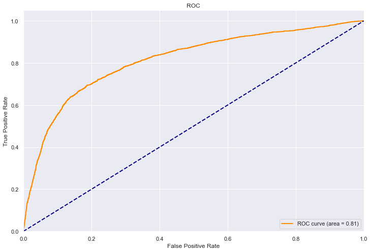

```python
plot_roc(y_val, y_prob[:,1])
```

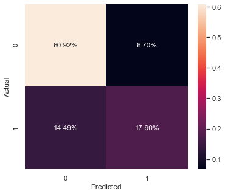

```python
plot_confusion(y_val, y_pred)
```

On the validation set, the model does not perform as well as the MLP Classifier. Especially the confusion matrix shows that it's not good at capturing true positives.

**On test data**

Again we test on the test data

```python
y_pred = lr_canc.predict(X_test)
y_prob = lr_canc.predict_proba(X_test)
```

```python
evaluate_model(y_test, y_pred)
```

```
F1 score 0.017566761752808264
Recall 0.09038142620232173
Precision 0.009728842000035702
Accuracy 0.8858285339701268
```

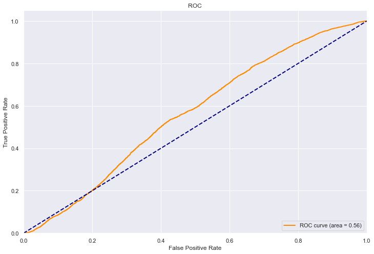

```python
plot_roc(y_test, y_prob[:,1])
```

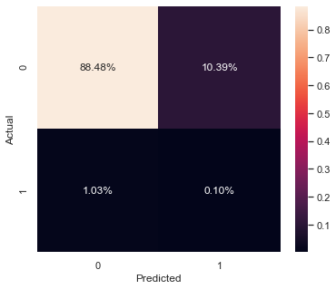

```python
plot_confusion(y_test, y_pred)
```

It is very clear that the model is completely useless on the test set, showing that it has overfitted on the 2019 data.

### Arrival delay

We will now predict arrival delays using logistic regression

```python
param_grid_lr = [
    {
        'penalty': ['elasticnet'],
        'solver': ['saga'],
        'n_jobs': [8],
        'l1_ratio': np.linspace(0.01, 0.2, 5),
        'max_iter': [400]
    }
]
```

```python
cv = StratifiedKFold(n_splits=5, random_state=42)
```

```python
lr_del = GridSearchCV(LogisticRegression(), param_grid_lr, cv=cv, scoring='f1', n_jobs=8, verbose=2)
```

```python
%%time
lr_del.fit(X_train_arr, y_train_arr)
```

```
Fitting 5 folds for each of 5 candidates, totalling 25 fits
```

```
[Parallel(n_jobs=8)]: Using backend LokyBackend with 8 concurrent workers.
[Parallel(n_jobs=8)]: Done  23 out of  25 | elapsed:  8.7min remaining:   45.3s
[Parallel(n_jobs=8)]: Done  25 out of  25 | elapsed: 10.7min finished
```

```
Wall time: 13min 35s
```

[output not shown]

```python
lr_del.cv_results_['mean_test_score']
```

```
array([0.58196852, 0.58196393, 0.58196393, 0.58195267, 0.58195267])
```

```python
lr_del.best_params_
```

[output not shown]

```python
y_prob = lr_del.predict_proba(X_val_arr)
y_pred = lr_del.predict(X_val_arr)
```

```python
evaluate_model(y_val_arr, y_pred)
```

```
F1 score 0.5797306874557051
Recall 0.5407430258692874
Precision 0.6247772289831458
Accuracy 0.6269736428256903
```

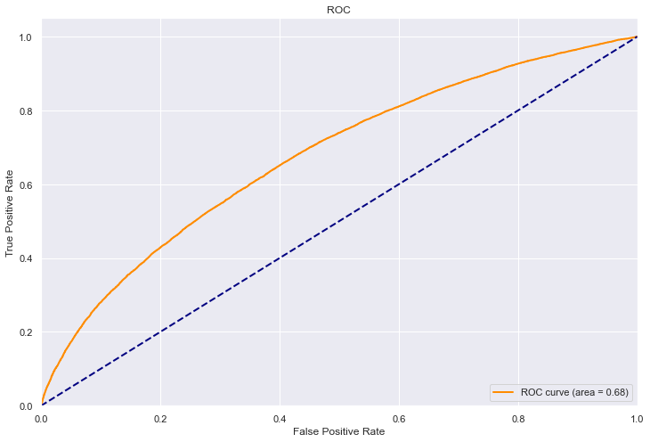

```python
plot_roc(y_val_arr, y_prob[:,1])
```

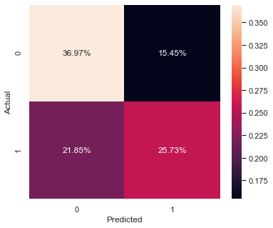

```python
plot_confusion(y_val_arr, y_pred)
```

It does not capture the true positives well, as many of the predictions (37%) are false positives or negatives.

**On test data**

```python
y_pred = lr_del.predict(X_test_arr)
y_prob = lr_del.predict_proba(X_test_arr)
```

```python
evaluate_model(y_test_arr, y_pred)
```

```
F1 score 0.24617723832386462
Recall 0.46211492766053175
Precision 0.16777780046555316
Accuracy 0.6180013891893739
```

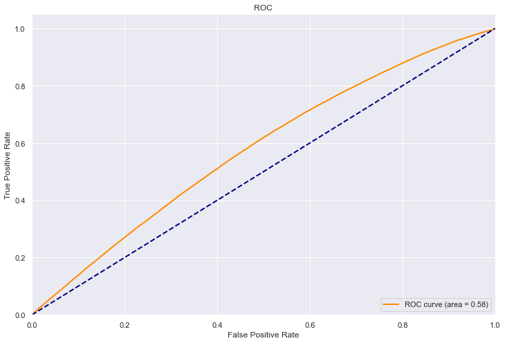

```python
plot_roc(y_test_arr, y_prob[:,1])
```

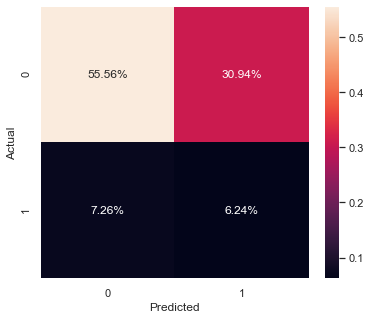

```python
plot_confusion(y_test_arr, y_pred)
```

The model shows the same signs as the MLP Classifier on arrival delays. Clear overfitting on the 2019 data.

## XGBoost

In this part of the Predictive modelling, we will use the XGBoost algorithm to predict the cancellations and arrival delays of the January 2020 flights.

```python
from sklearn.model_selection import StratifiedKFold

from xgboost import XGBClassifier
import shap
```

### Cancellations

We will first start predicting the cancellations of the flights. As the number of cancellations is much lower than the non-cancelled ones, we will estimate what weight should the cancellations have using the train data, in order to improve the accuracy of our model.

```python
# CANCELLED weight estimator
import collections
counter = collections.Counter(y_train)
#estimate scale_pos_weight value
estimate_c = counter[0] / counter[1]
print('Estimate: %.3f' % estimate_c)
counter
```

```
Estimate: 2.088
```

```
Counter({0: 22500, 1: 10775})
```

The estimated weight of the cancellations is 2.088, which will be used in the model. We will now define the model and see what is the cross validation score of the XGBoost Classifier.

```python
# define model
params = {'n_estimators': 60, 'max_depth': 10, 'learning_rate': 0.00025, 'scale_pos_weight': estimate_c}
xgb_canc = XGBClassifier(**params)

# define evaluation procedure
cv = StratifiedKFold(n_splits=5, random_state=42)

# evaluate model
scores = cross_val_score(xgb_canc, X_train, y_train, scoring='f1', cv=cv, n_jobs=8, verbose=2)
scores
```

```
[Parallel(n_jobs=8)]: Using backend LokyBackend with 8 concurrent workers.
[Parallel(n_jobs=8)]: Done   2 out of   5 | elapsed:    7.1s remaining:   10.7s
[Parallel(n_jobs=8)]: Done   5 out of   5 | elapsed:    7.2s remaining:    0.0s
[Parallel(n_jobs=8)]: Done   5 out of   5 | elapsed:    7.2s finished
```

```
array([0.75051358, 0.76839484, 0.74725767, 0.75572869, 0.74724265])
```

```python
xgb_canc.fit(X_train, y_train)
```

```
[18:06:43] WARNING: C:/Users/Administrator/workspace/xgboost-win64_release_1.4.0/src/learner.cc:1095: Starting in XGBoost 1.3.0, the default evaluation metric used with the objective 'binary:logistic' was changed from 'error' to 'logloss'. Explicitly set eval_metric if you'd like to restore the old …
```

```
XGBClassifier(base_score=0.5, booster='gbtree', colsample_bylevel=1,
              colsample_bynode=1, colsample_bytree=1, gamma=0, gpu_id=-1,
              importance_type='gain', interaction_constraints='',
              learning_rate=0.00025, max_delta_step=0, max_depth=10,
              min_child_weight=1, missing=nan, monotone_constraints='()',
              n_estimators=60, n_jobs=8, num_parallel_tree=1, random_state=0,
              reg_alpha=0, reg_lambda=1, scale_pos_weight=2.0881670533642693,
              subsample=1, tree_method='exact', validate_parameters=1,
              verbosity=None)
```

```python
y_pred = xgb_canc.predict(X_val)
y_prob = xgb_canc.predict_proba(X_val)
```

```python
evaluate_model(y_val, y_pred)
```

```
F1 score 0.7631796853436378
Recall 0.7697661469933185
Precision 0.7567049808429118
Accuracy 0.8452939055174901
```

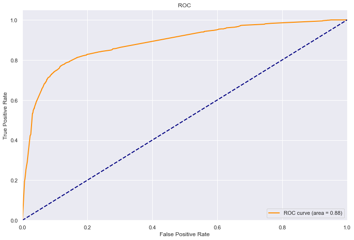

```python
plot_roc(y_val, y_prob[:,1])
```

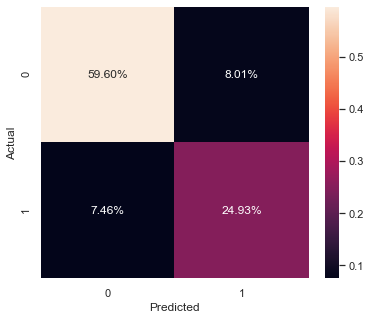

```python
plot_confusion(y_val, y_pred)
```

```python
explainer = shap.Explainer(xgb_canc, X_val, feature_names=features)
shap_values = explainer(X_val)
```

```
 99%|===================| 11026/11092 [00:52<00:00]
```

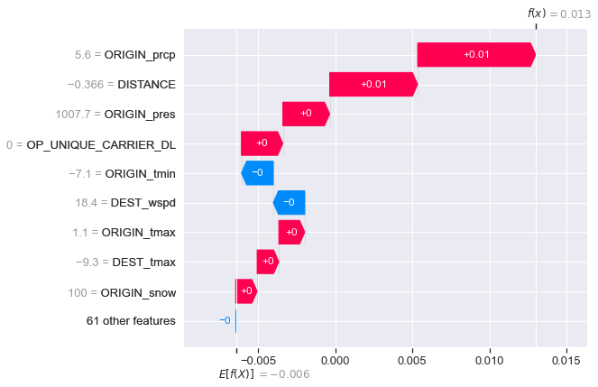

```python
shap.plots.waterfall(shap_values[0])
```

From the SHAP values, it is clear that precipitation at the origin, the distance, type of carrier, temperature, snow and windspeed has an effect on cancelling a flight or not.

**On test data**

Let's now test our model with the January 2020 dataset.

```python
y_pred = xgb_canc.predict(X_test)
y_prob = xgb_canc.predict_proba(X_test)
```

```python
evaluate_model(y_test, y_pred)
```

```
F1 score 0.026751624566992843
Recall 0.17545605306799336
Precision 0.014479662779876279
Accuracy 0.8558187011284356
```

Let's now look into the ROC-curve and the confussion matrix to visualize this performance.

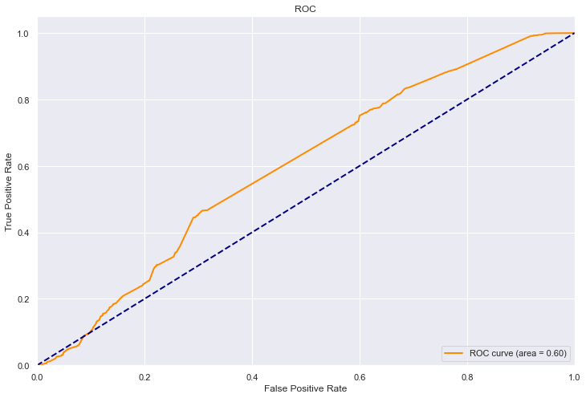

```python
plot_roc(y_test, y_prob[:,1])
```

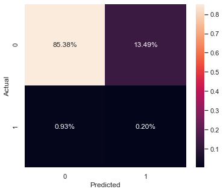

```python
plot_confusion(y_test, y_pred)
```

As visualized in the plots above, we can see that the rate of false positives is really large compared to the true positives, which is actually non-existant (0.2%). Therefore, it can be stated that we have a bias on 2019 due to weather data which causes that we are not able to predict cancellations in 2020.

### Arrival delay

We will now use the XGBoost classifier to predict the arrival delay of the flights. In the first step, as done previously, we will estimate the weight of the arrival delays variable to make the model more accurate.

```python
# ARR_DEL15 weight estimator
import collections
counter = collections.Counter(y_train_arr)
#estimate scale_pos_weight value
estimate_c = counter[0] / counter[1]
print('Estimate: %.3f' % estimate_c)
counter
```

```
Estimate: 1.102
```

```
Counter({0.0: 75000, 1.0: 68070})
```

```python
# define model
params = {'n_estimators': 60, 'max_depth': 10, 'learning_rate': 0.00025, 'scale_pos_weight': estimate_c}
xgb_del = XGBClassifier(**params)

# define evaluation procedure
cv = StratifiedKFold(n_splits=5, random_state=42)

# evaluate model
scores = cross_val_score(xgb_del, X_train_arr, y_train_arr, scoring='f1', cv=cv, n_jobs=8, verbose=2)
scores
```

```
[Parallel(n_jobs=8)]: Using backend LokyBackend with 8 concurrent workers.
[Parallel(n_jobs=8)]: Done   2 out of   5 | elapsed:   25.6s remaining:   38.5s
[Parallel(n_jobs=8)]: Done   5 out of   5 | elapsed:   26.4s remaining:    0.0s
[Parallel(n_jobs=8)]: Done   5 out of   5 | elapsed:   26.4s finished
```

```
array([0.6197682 , 0.60948276, 0.59902551, 0.61148229, 0.58674328])
```

```python
xgb_del.fit(X_train_arr, y_train_arr)
```

```
[18:07:14] WARNING: C:/Users/Administrator/workspace/xgboost-win64_release_1.4.0/src/learner.cc:1095: Starting in XGBoost 1.3.0, the default evaluation metric used with the objective 'binary:logistic' was changed from 'error' to 'logloss'. Explicitly set eval_metric if you'd like to restore the old …
```

```
XGBClassifier(base_score=0.5, booster='gbtree', colsample_bylevel=1,
              colsample_bynode=1, colsample_bytree=1, gamma=0, gpu_id=-1,
              importance_type='gain', interaction_constraints='',
              learning_rate=0.00025, max_delta_step=0, max_depth=10,
              min_child_weight=1, missing=nan, monotone_constraints='()',
              n_estimators=60, n_jobs=8, num_parallel_tree=1, random_state=0,
              reg_alpha=0, reg_lambda=1, scale_pos_weight=1.1018069634200087,
              subsample=1, tree_method='exact', validate_parameters=1,
              verbosity=None)
```

```python
y_pred = xgb_del.predict(X_val_arr)
y_prob = xgb_del.predict_proba(X_val_arr)
```

```python
evaluate_model(y_val_arr, y_pred)
```

```
F1 score 0.5993203432511063
Recall 0.5401701114979507
Precision 0.6730177904678234
Accuracy 0.65635025476505
```

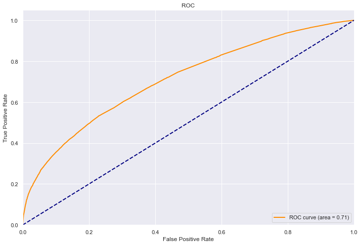

```python
plot_roc(y_val_arr, y_prob[:, 1])
```

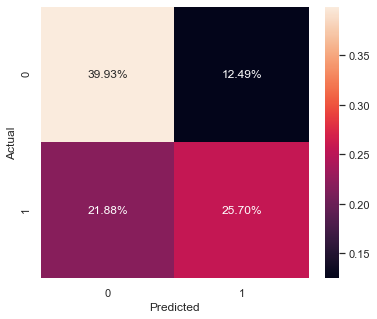

```python
plot_confusion(y_val_arr, y_pred)
```

By looking into the displayed data, the validation of the results are not as good as expected as it guessess incorrectly a considerably amount of positive values.

```python
explainer = shap.Explainer(xgb_del, X_val_arr, feature_names=features_arr)
shap_values = explainer(X_val_arr)
```

```
100%|===================| 47551/47691 [03:44<00:00]
```

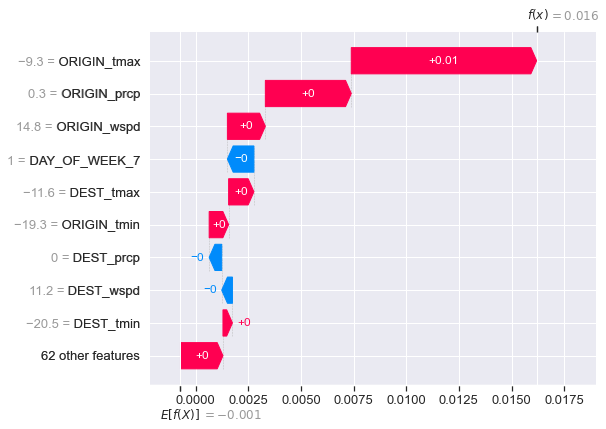

```python
shap.plots.waterfall(shap_values[0])
```

**On test data**

In order to test the performance of the model, we will test the XGBoost classifier on the January 2020 data in order to see if we can correctly predict arrival delays in the future.

```python
y_pred = xgb_del.predict(X_test_arr)
y_prob = xgb_del.predict_proba(X_test_arr)
```

```python
evaluate_model(y_test_arr, y_pred)
```

```
F1 score 0.23914171012705274
Recall 0.4116530517554096
Precision 0.16852005341437584
Accuracy 0.6464342241605083
```

By looking into the F1 score, we can state that the XGBoost model is better at predicting flight delays than cancellations. However, it still has a very low value which is analized by displaying the plots below.

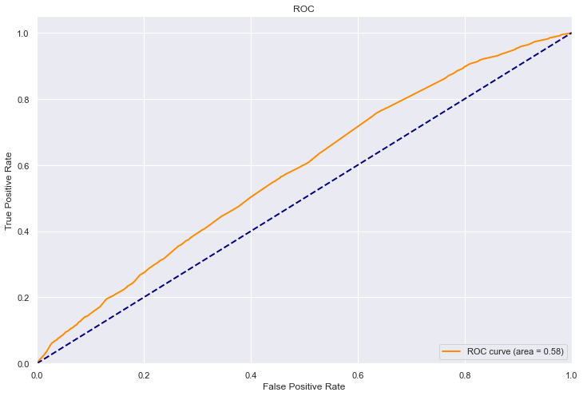

```python
plot_roc(y_test_arr, y_prob[:,1])
```

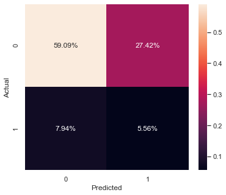

```python
plot_confusion(y_test_arr, y_pred)
```

By looking into the ROC curve and the confussion matrix, we can see that the model has a problem predicting correctly the arrival delays, as the majority of flights it predicts to having an arrival delay are wrong.

## Conclusion

The models were capable of performing very well on the train and validation dataset, being the 2019 data.

For predicting flight cancellations, the best performing model turned out to be XGBoost, with an area under the ROC curve of 0.88 and F1 score of 0.76.

For predicting flight delays, the best performing model turned out to be XGBoost, with an area under the ROC curve of 0.71 and F1 score of 0.60.

However... the models were rendered useless when testing on the test data from 2020. Following the insights gained from the exploratory analysis, this makes sense. In January 2019, the US government and two snow storms caused the airports to shut down.

We are therefore seeing the example of *correlation vs causality* in terms of the models finding the correlation in 2019, but not the cause behind the cancellations or delays, as it performs poorly on the test data. Even if it was provided with the weather data as features.

It was therefore not possible to predict either cancellations or delays.

## Future work

To improve the predictive models one could take a few approaches.

First we discussed the possiblity of adding more data, such as activity of airports (could be derived) and getting the expected departure and arrival times (strange that it wasn't present in the first place). These features could potentially have better correlation with the targets.

Moreover, one could remove the detected anomalies from the dataset, such as the snowstorms and shutdown of airports. This will make the dataset more general and hopefully improve the models ability to explain cause and not correlation.

Finally, one could merge the two datasets, 2019 and 2020, but this might cause issues when predicting for 2021..